# Gráfico de dispersão e Matriz de correlação

Após a seleção de variáveis o problema estatístico postulado dizia respeito a perceber a associação da inicidência de casos de arboviroses com as variáveis selecionadas para compor a análise.

O primeiro passo foi fazer o gráfico de dispersão das variáveis candidatas (eixo horizontal) versus a incidência das arboviroses (eixo vertical), usando os pares de informações de todos para todo o período. Apenas as variáveis numéricas foram escolhidas para a análise, sendo excluídas, assim, as categóricas.

Desta forma, as seguintes variáveis foram trabalhadas:

1. dens_mean = representa a densidade média entre os anos 2016 a 2019 para cada municipio;
2. percent_medio_ab = percentual médio de cobertura AB para os anos 2016 a 2019, por municipio;
3. IFDM_geral_2016= Indice FIRJAN de Desenvolvimento Municipal (IFDM);
4. SNIS_G12A_2015: contabiliza a População total residente do(s) município(s) com abastecimento de água, segundo o IBGE/ Habitantes. Ano de análise 2015.
5. SNIS_G12B_2015:representa a População total residente do(s) município(s) com esgotamento sanitário, segundo o IBGE/ Habitantes
6. mediaciclo22: Número médio de ciclos que atingiram mínimo de 80% de cobertura de imóveis visitados para controle vetorial da dengue.

# 1 Grafico de dispersão

Pouco se pode afirmar sobre o desempenho das variáveis de saneamento básico. O alto grau de missing e o fato de não cobirem todos os municipios, mostra-se como um fator limitante para uso.

## 1.1 Dengue

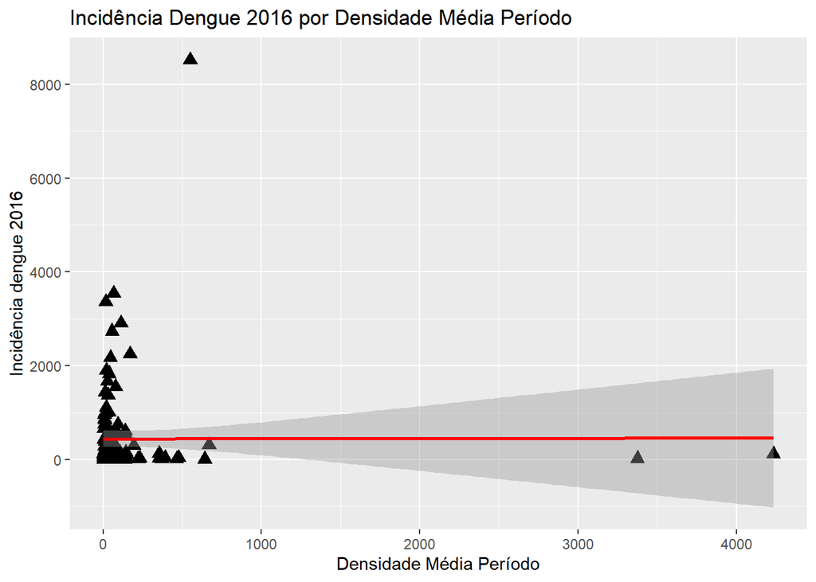

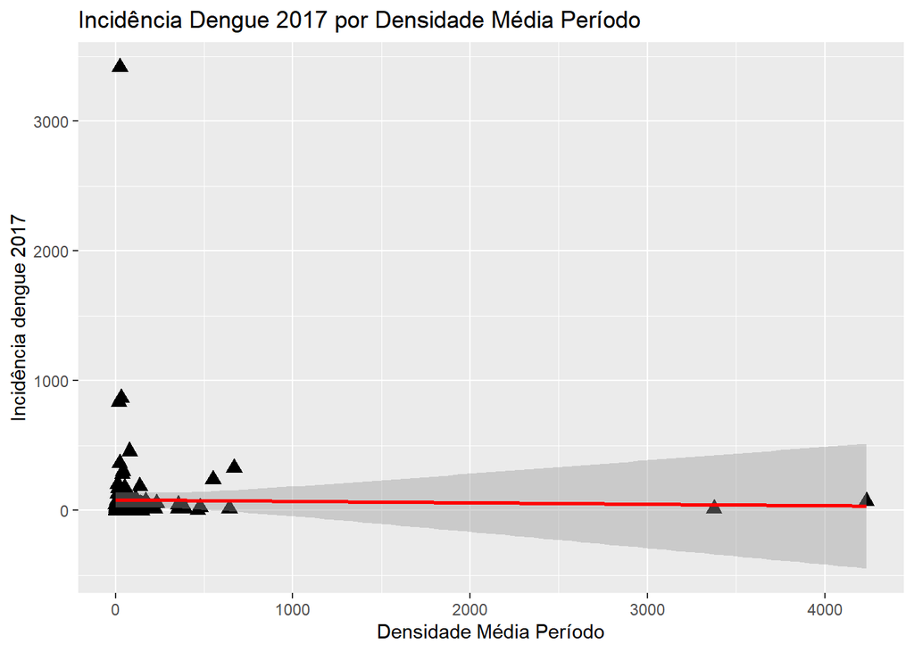

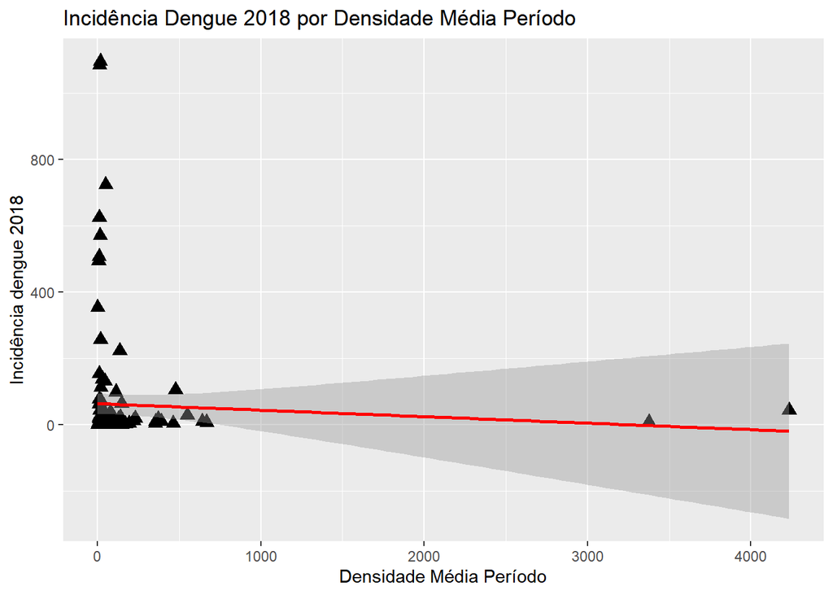

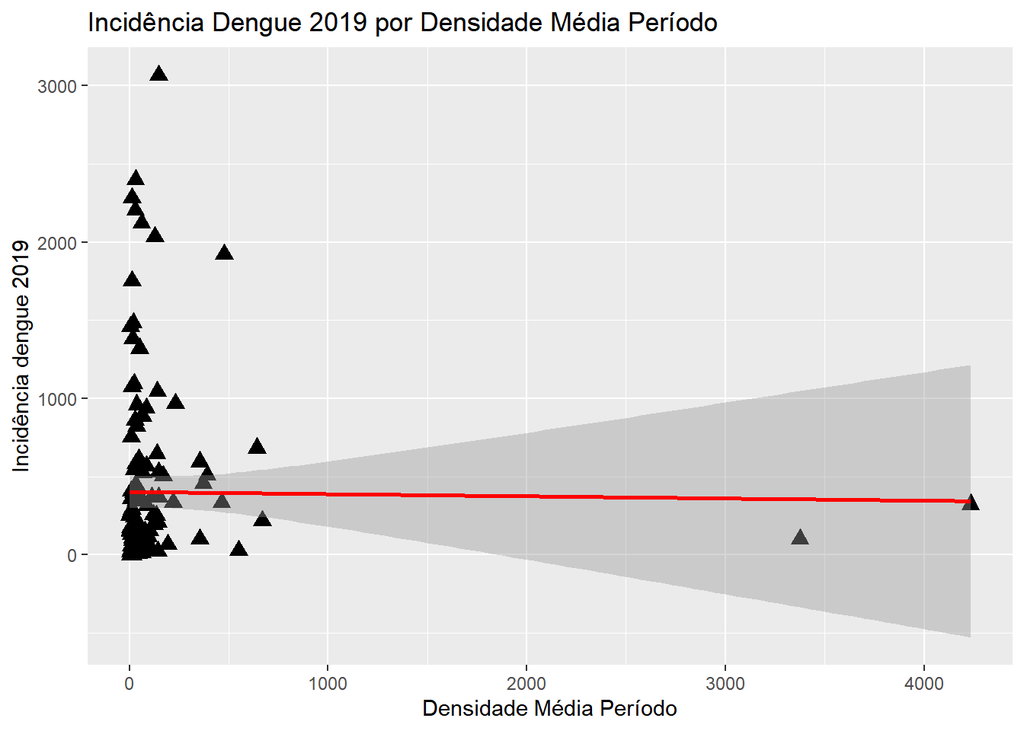

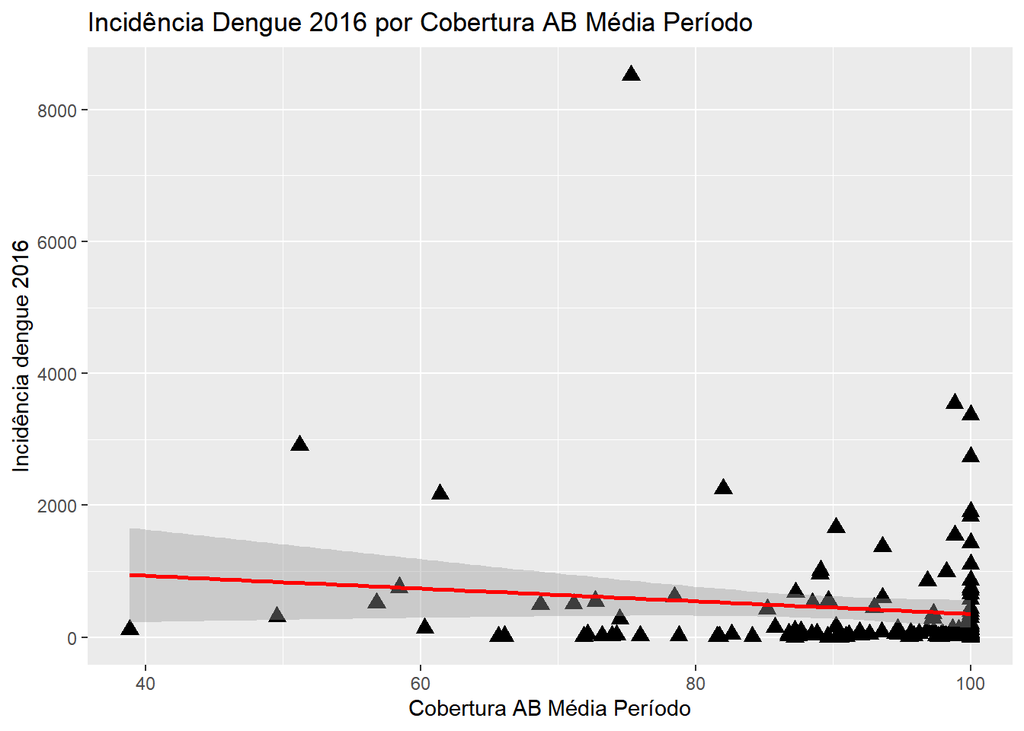

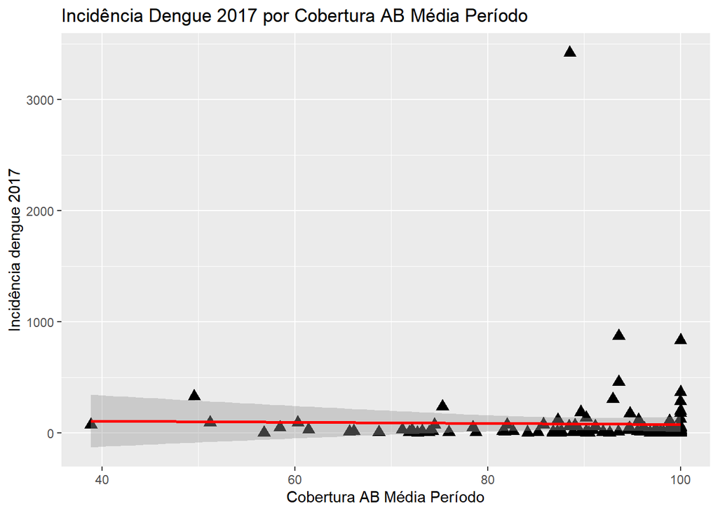

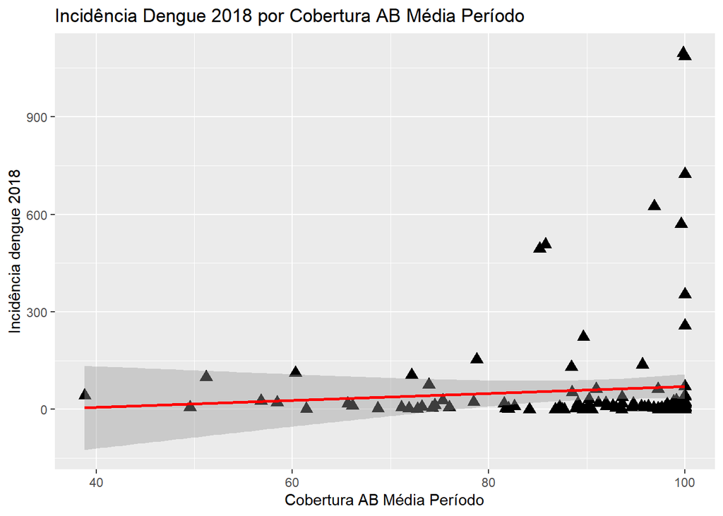

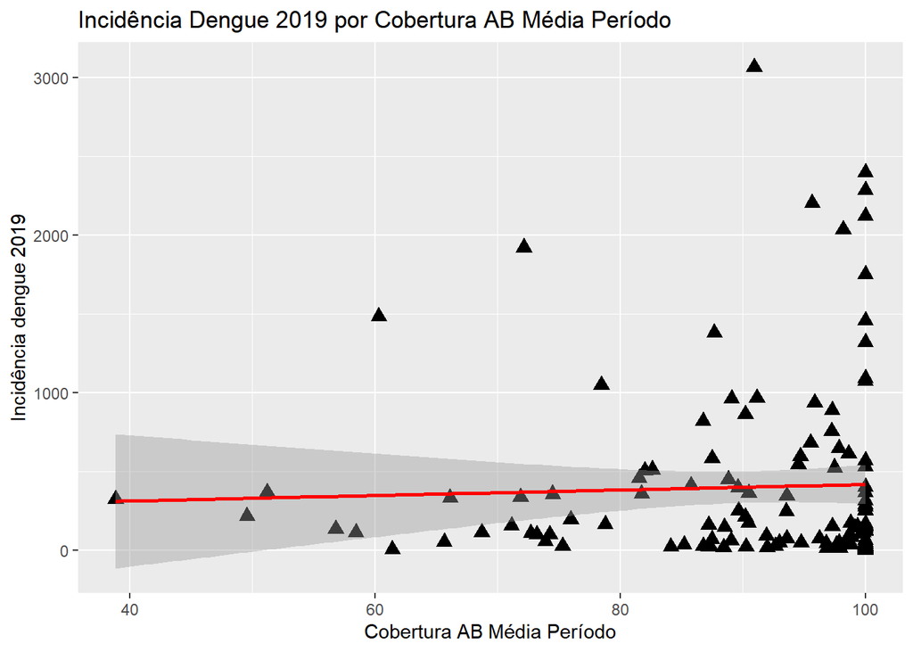

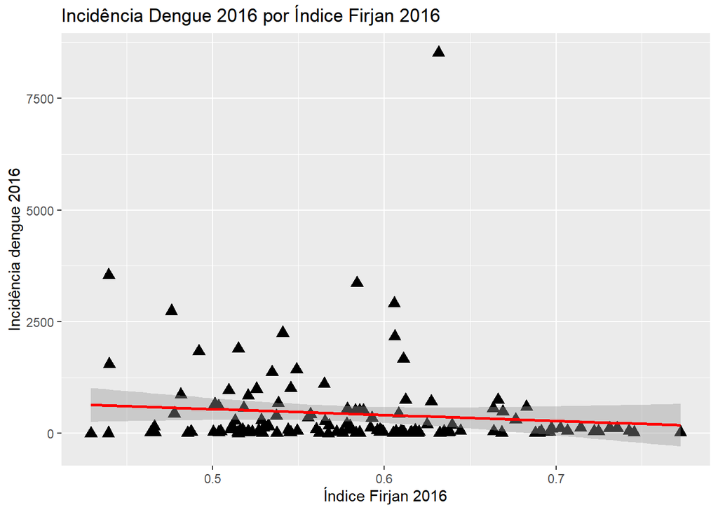

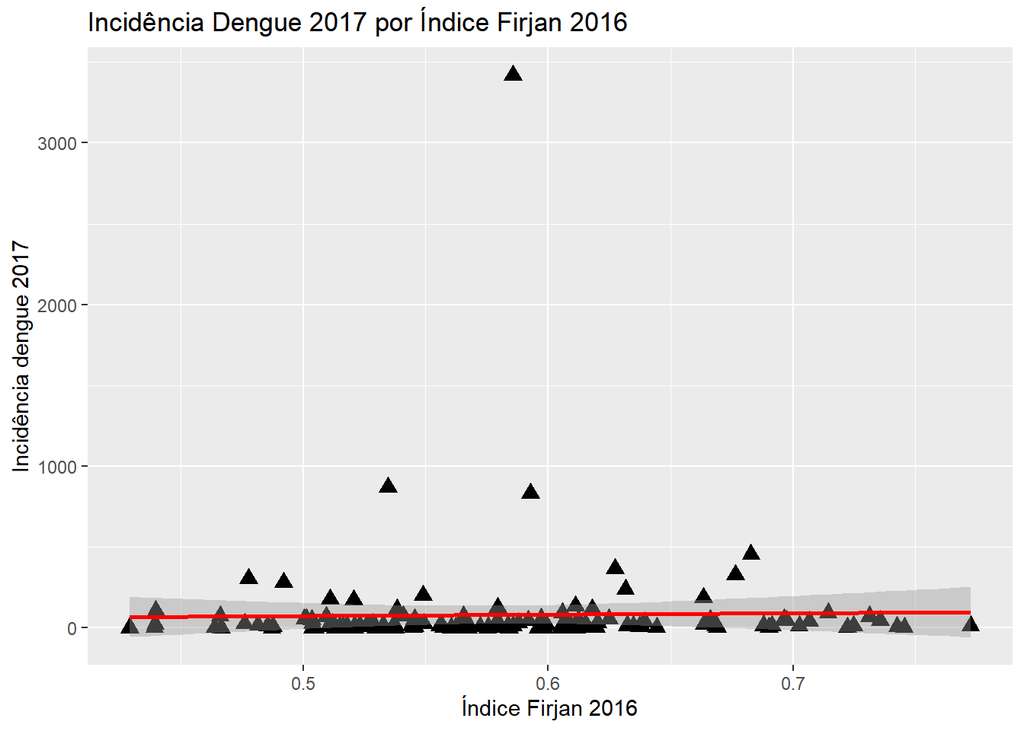

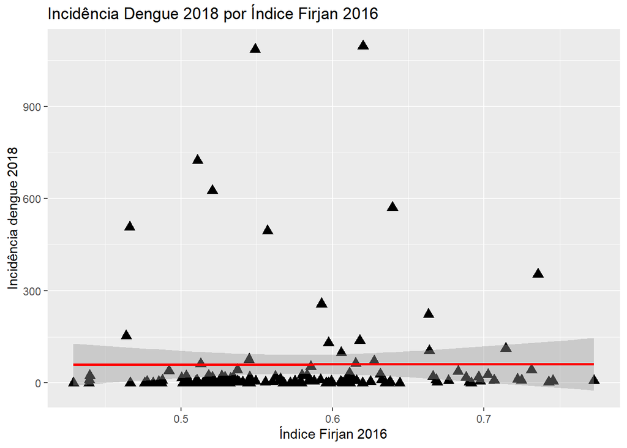

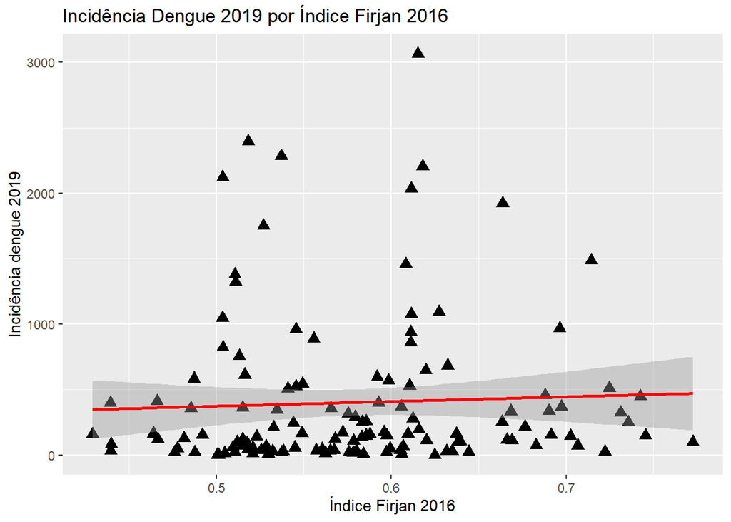

[12 more figures not shown]

## 1.2 Chikungunya

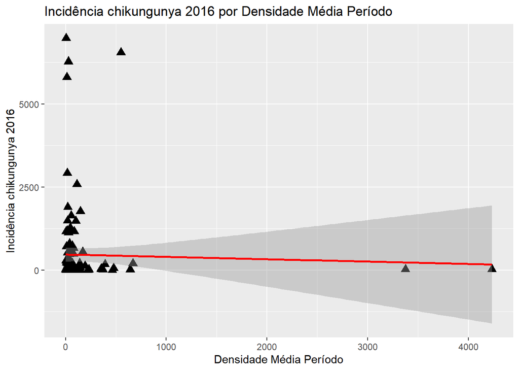

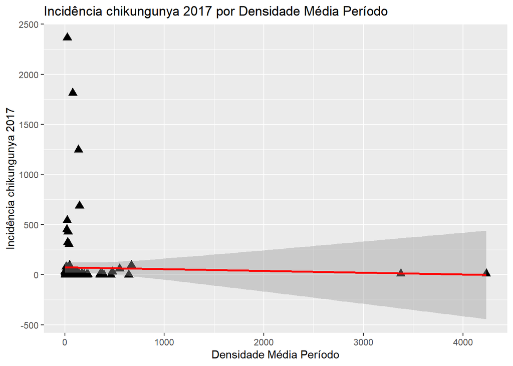

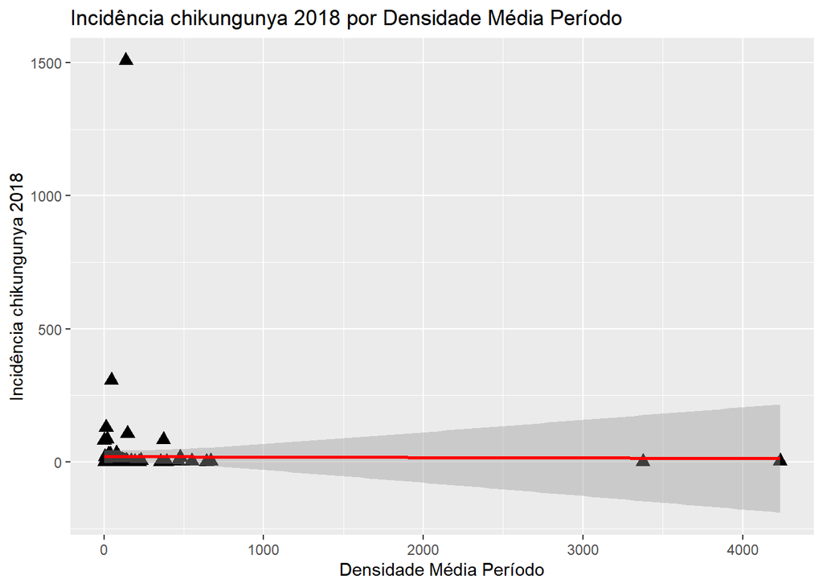

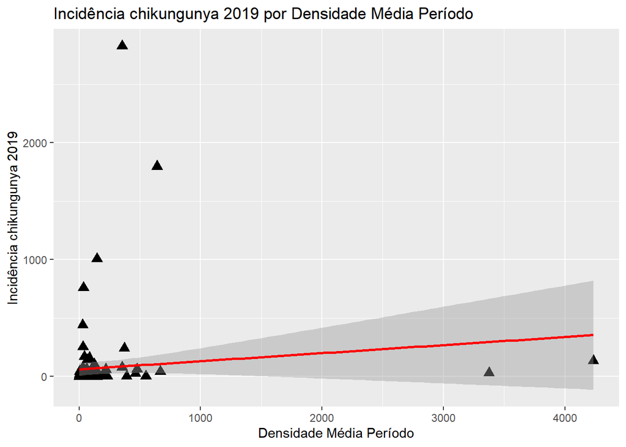

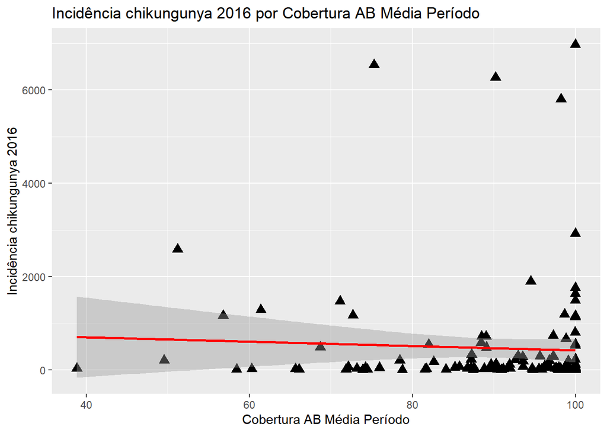

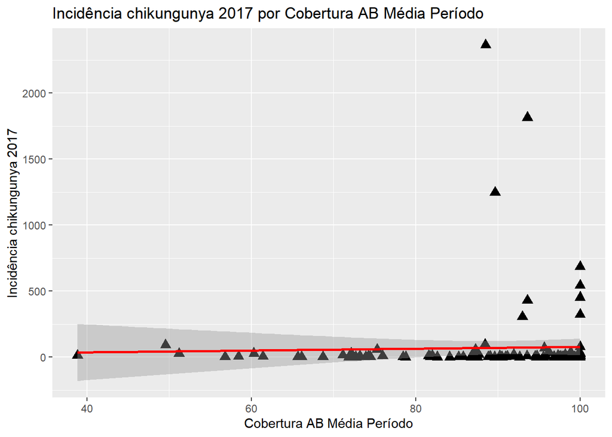

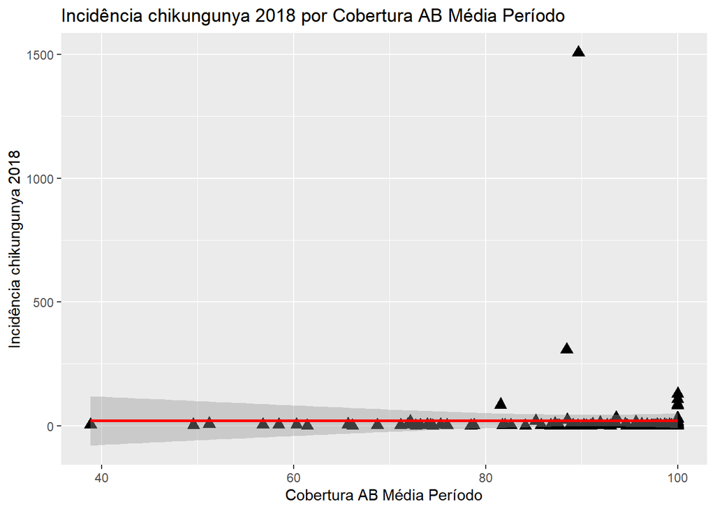

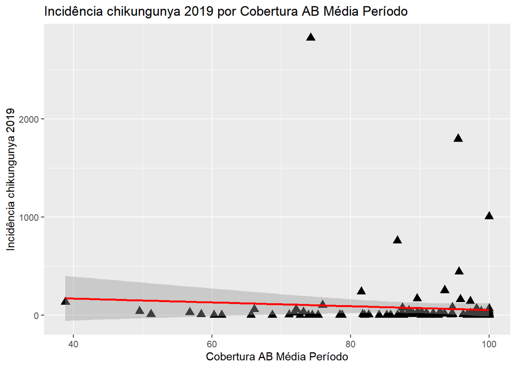

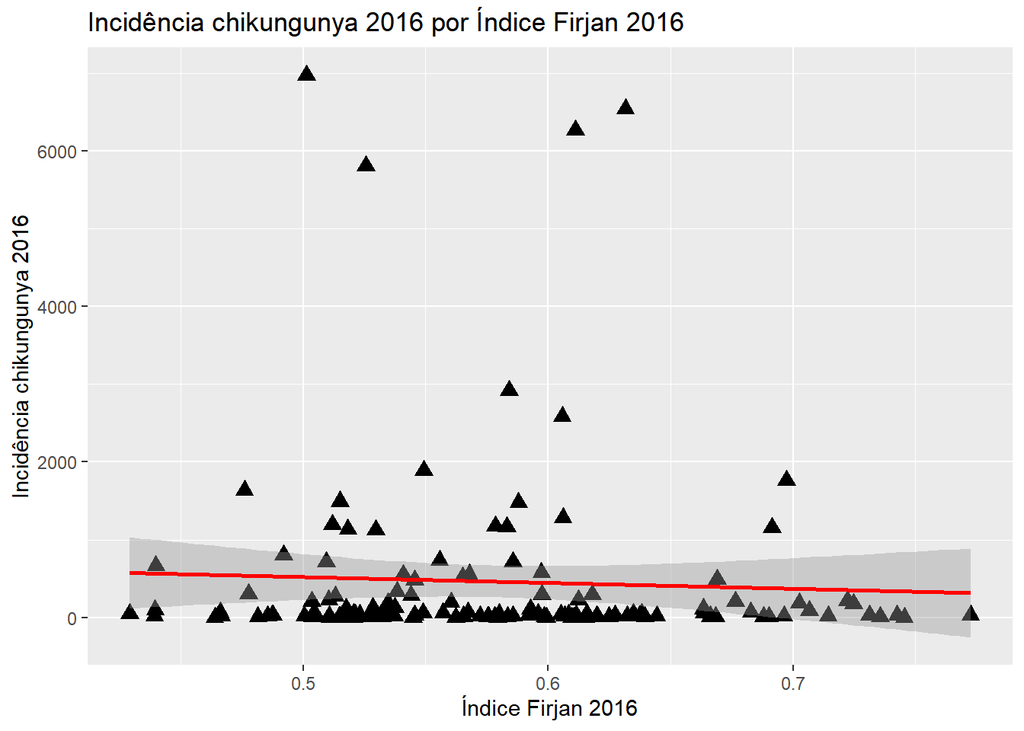

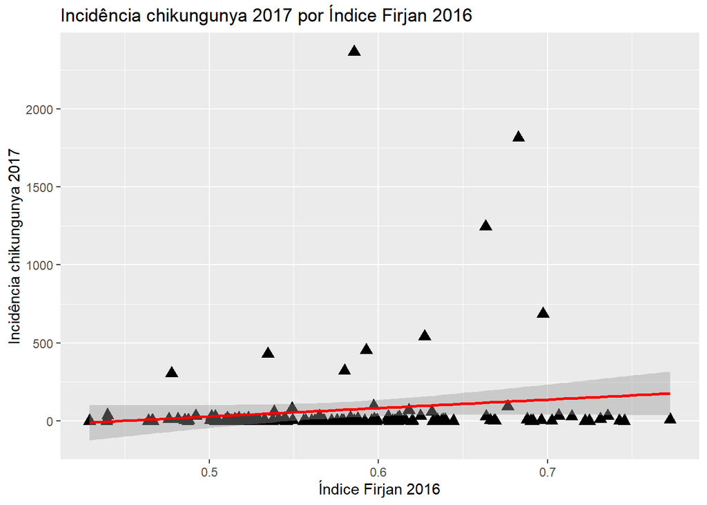

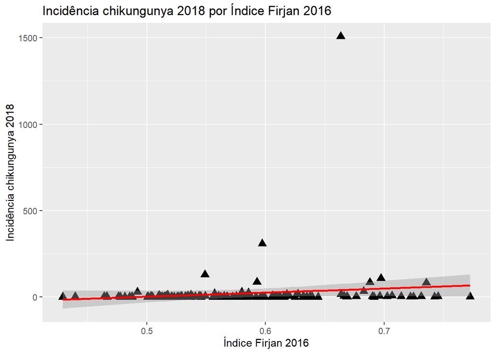

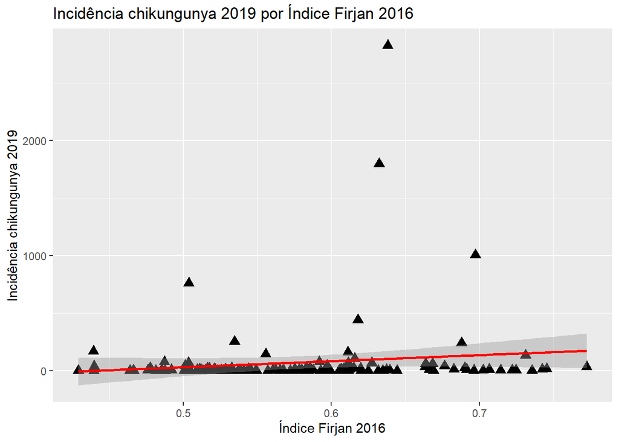

[12 more figures not shown]

## 1.3 Zika

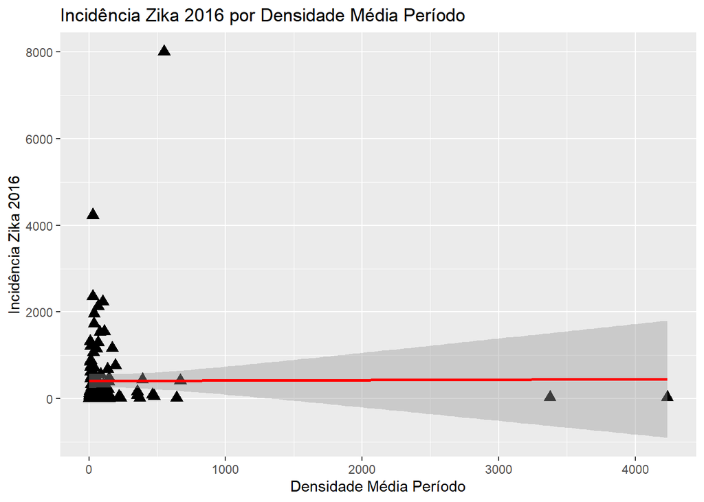

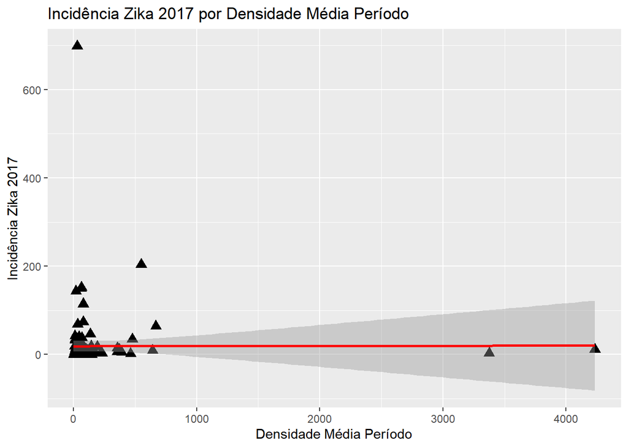

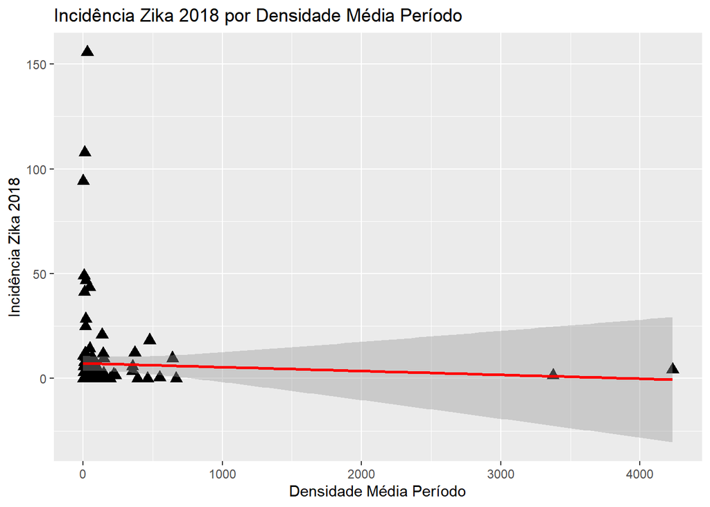

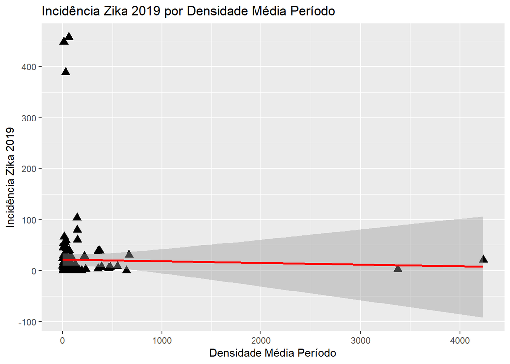

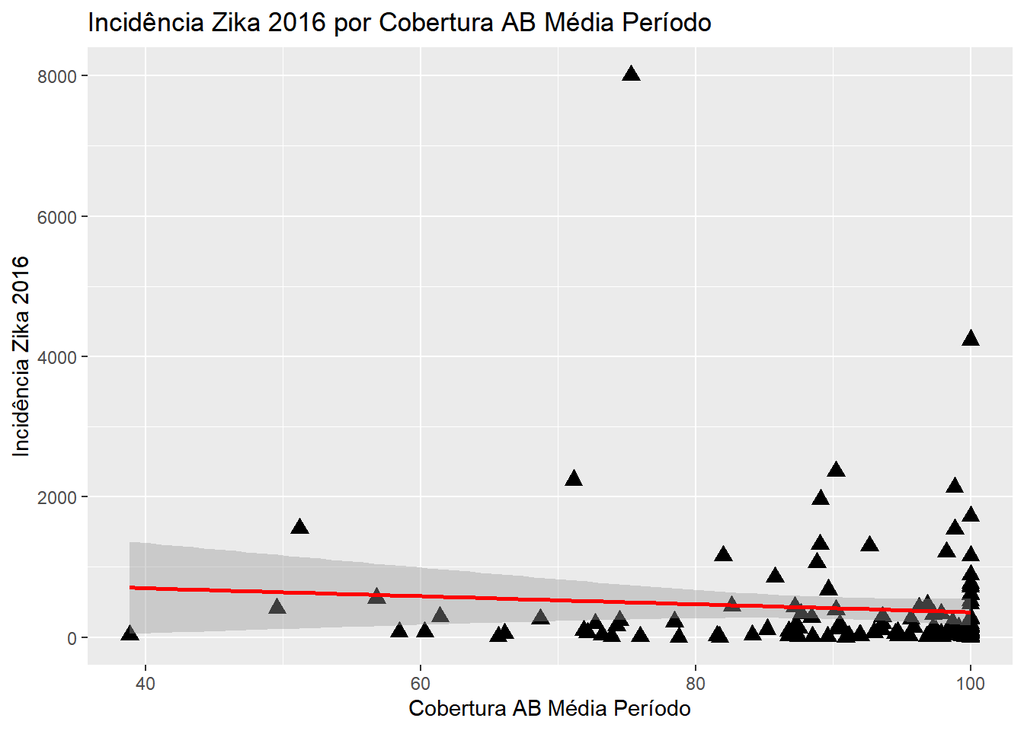

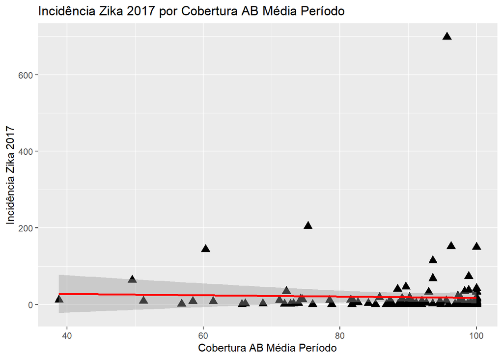

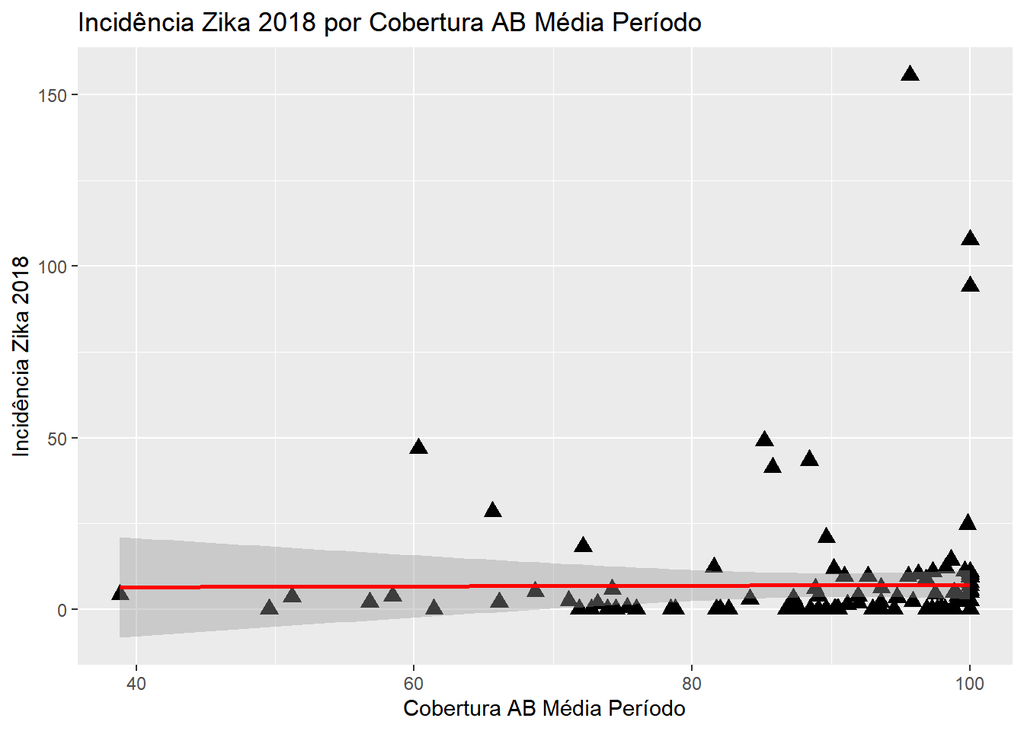

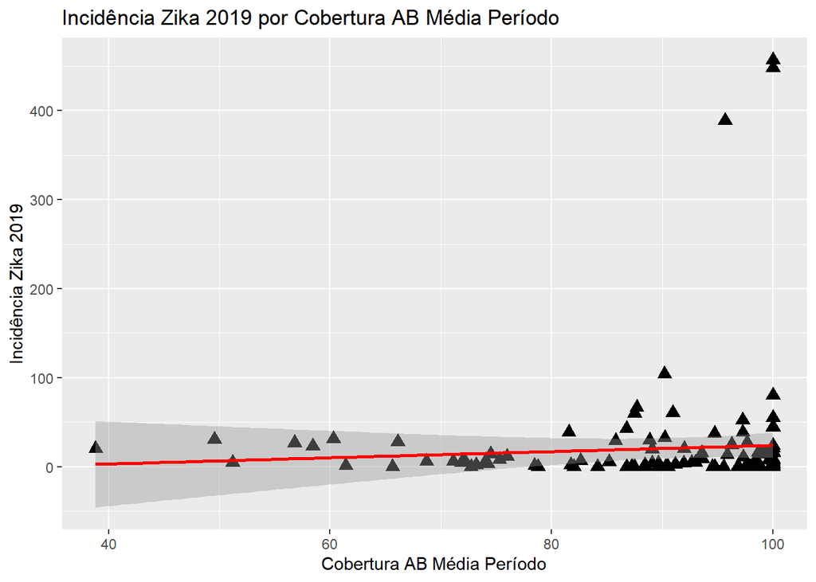